# Análise de vendas de uma cafeteria

## Teste de apresentação com Jupyter Notebook

Exemplo com:

- tabelas;
- fórmulas em LaTeX;
- código Python;
- gráficos;
- diferentes tipos de slides.

## Objetivos do exemplo

Ao final desta apresentação, queremos testar:

- a criação de slides horizontais;
- a criação de subslides verticais;
- o aparecimento progressivo de conteúdo;
- a exibição de tabelas;
- a renderização de equações;
- a inclusão de código e resultados.

## Dados da cafeteria

A cafeteria registrou as seguintes vendas:

| Produto | Quantidade | Preço unitário |
| --- | --- | --- |
| Café | 120 | R$ 6,00 |
| Cappuccino | 80 | R$ 9,00 |
| Chá | 50 | R$ 5,00 |
| Bolo | 40 | R$ 12,00 |

### Pergunta

Qual produto gerou o maior faturamento?

O faturamento de cada produto será calculado por:

$$ \text{Faturamento} = \text{Quantidade} \times \text{Preço unitário} $$

```python
produtos = ["Café", "Cappuccino", "Chá", "Bolo"]
quantidades = [120, 80, 50, 40]
precos = [6, 9, 5, 12]

faturamentos = [
    quantidade * preco
    for quantidade, preco in zip(quantidades, precos)
]

faturamentos
```

```
[720, 720, 250, 480]
```

## Interpretação dos resultados

Os faturamentos foram:

| Produto | Faturamento |
| --- | --- |
| Café | R$ 720,00 |
| Cappuccino | R$ 720,00 |
| Chá | R$ 250,00 |
| Bolo | R$ 480,00 |

Café e cappuccino apresentaram o mesmo faturamento.

### Primeira conclusão

O produto com maior preço não foi necessariamente aquele com maior faturamento.

### Segunda conclusão

O faturamento depende simultaneamente de:

- quantidade vendida;
- preço unitário.

## Representação matemática

Para cada produto $i$, podemos definir:

$$ F_i = q_i p_i $$

em que:

- $F_i$ é o faturamento;
- $q_i$ é a quantidade vendida;
- $p_i$ é o preço unitário.

O faturamento total é:

$$ F_{\text{total}} = \sum_{i=1}^{n} q_i p_i $$

```python
faturamento_total = sum(faturamentos)

print(f"Faturamento total: R$ {faturamento_total:,.2f}")
```

```
Faturamento total: R$ 2,170.00
```

## Organizando os dados com pandas

Agora construiremos uma tabela usando um `DataFrame`.

```python
import pandas as pd

dados = pd.DataFrame({
    "Produto": produtos,
    "Quantidade": quantidades,
    "Preço": precos,
    "Faturamento": faturamentos
})

dados
```

|  | Produto | Quantidade | Preço | Faturamento |
| --- | --- | --- | --- | --- |
| 0 | Café | 120 | 6 | 720 |
| 1 | Cappuccino | 80 | 9 | 720 |
| 2 | Chá | 50 | 5 | 250 |
| 3 | Bolo | 40 | 12 | 480 |

```python
dados["Participação (%)"] = (
    dados["Faturamento"]
    / dados["Faturamento"].sum()
    * 100
)

dados
```

|  | Produto | Quantidade | Preço | Faturamento | Participação (%) |
| --- | --- | --- | --- | --- | --- |
| 0 | Café | 120 | 6 | 720 | 33.179724 |
| 1 | Cappuccino | 80 | 9 | 720 | 33.179724 |
| 2 | Chá | 50 | 5 | 250 | 11.520737 |
| 3 | Bolo | 40 | 12 | 480 | 22.119816 |

## Visualização dos faturamentos

O gráfico permite comparar rapidamente os produtos.

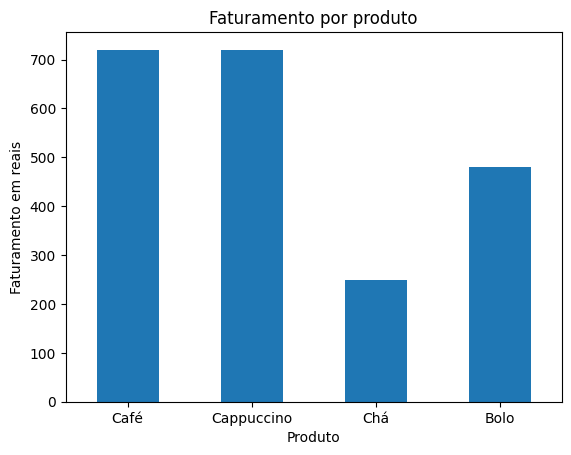

```python
import matplotlib.pyplot as plt

dados.plot(
    x="Produto",
    y="Faturamento",
    kind="bar",
    legend=False
)

plt.title("Faturamento por produto")
plt.ylabel("Faturamento em reais")
plt.xlabel("Produto")
plt.xticks(rotation=0)
plt.show()
```

## Exercício rápido

Considere um novo produto:

| Produto | Quantidade | Preço |
| --- | --- | --- |
| Sanduíche | 35 | R$ 15,00 |

Calcule:

1. o faturamento do sanduíche;
2. o novo faturamento total;
3. sua participação percentual no faturamento.

```python
quantidade_sanduiche = 35
preco_sanduiche = 15

faturamento_sanduiche = quantidade_sanduiche * preco_sanduiche
novo_total = faturamento_total + faturamento_sanduiche

participacao = faturamento_sanduiche / novo_total * 100

print("Faturamento do sanduíche:", faturamento_sanduiche)
print("Novo faturamento total:", novo_total)
print(f"Participação: {participacao:.2f}%")
```

```
Faturamento do sanduíche: 525
Novo faturamento total: 2695
Participação: 19.48%
```

## Resumo das opções testadas

| Tipo | Função |
| --- | --- |
| `slide` | Inicia um slide horizontal |
| `subslide` | Cria um slide vertical |
| `fragment` | Mostra a célula progressivamente |
| `notes` | Adiciona notas do apresentador |
| `skip` | Retira a célula da apresentação |
| sem tipo | Continua no slide anterior |

### Conteúdos também testados

- tabela escrita em Markdown;
- fórmulas em LaTeX;
- código Python;
- resultado numérico;
- DataFrame do pandas;
- gráfico do Matplotlib.

# Fim do teste

## Próximo passo

Usar essa estrutura como modelo para as aulas de Python para análise de dados.